# UCT 2022 final assignment

Uzma

5/26/2022

## Question 1

This section provides results on analysis of interventions that try to promote growth mindsets in children learning to read. There are two groups in the analysis, namely a control group (control), and an intervention group (growth, or growth_mindset). The control group receives the usual classroom activities, whereas the growth mindset group spends an hour each week of the year doing activities aimed at promoting a growth mindset. Each child is tested at the beginning of the program (January), and then halfway through the program (June), and again at the end of the program (December). The analysis will provide descriptive statistics of the results between the 2 groups.

### 1.1 Explore the data descriptively, creating appropriate tables and figures, where needed.

Loading essential libraries

Loading the RDs files by the below command

We can use the `'clean names` command from the `janitor` package to clean column names according to tutorial 1 by the below code

Getting summary statistics of the individual dataset.

|  | participant_id | time | reading_score |
| --- | --- | --- | --- |
|  | Min. :1.0 | Length:15 | Min. : 7.00 |
|  | 1st Qu.:4.0 | Class :character | 1st Qu.: 9.00 |
|  | Median :6.0 | Mode :character | Median :14.00 |
|  | Mean :5.4 | NA | Mean :14.33 |
|  | 3rd Qu.:7.0 | NA | 3rd Qu.:17.50 |
|  | Max. :9.0 | NA | Max. :22.00 |

|  | participant_id | time | reading_score |
| --- | --- | --- | --- |
|  | Min. : 2.0 | Length:15 | Min. : 9.00 |
|  | 1st Qu.: 3.0 | Class :character | 1st Qu.:11.00 |
|  | Median : 5.0 | Mode :character | Median :19.50 |
|  | Mean : 5.6 | NA | Mean :18.93 |
|  | 3rd Qu.: 8.0 | NA | 3rd Qu.:26.00 |
|  | Max. :10.0 | NA | Max. :32.00 |
|  | NA | NA | NA’s :1 |

Individual summary statistics showed that there is one participant in growth for which there is no data available for score while for control group all data is given. The quartiles are given which will be analysed by box plot later. We row wise bind two datasets below.

Joining the two datasets and viewing data types in the columns

```
## Classes 'data.table' and 'data.frame':   30 obs. of  3 variables:
##  $ participant_id: int  1 1 1 4 4 4 6 6 6 7 ...
##  $ time          : chr  "January" "June" "December" "January" ...
##  $ reading_score : num  9 14 22 9 13 18 7 9 16 9 ...
##  - attr(*, ".internal.selfref")=<externalptr>
```

The following table provides descriptive statistics of the two groups regards reading scores, The mean is the arithmetic average while the standard deviation measures how far the results deviate from the mean. Notably, the standard deviation is larger than 2 for reading_scores, showing that the score range was large: minimum was 7 and maximum 32 for the entire group. On the other hand the time taken by the individual groups is not varying much between max and minimun values. Moreover the median value is 16 which can also be visualized with the help of boxplots below.

|  | vars | n | mean | sd | median | trimmed | mad | min | max | range | skew | kurtosis | se |
| --- | --- | --- | --- | --- | --- | --- | --- | --- | --- | --- | --- | --- | --- |
| participant_id | 1 | 30 | 5.50000 | 2.9213837 | 5.5 | 5.50 | 3.7065 | 1 | 10 | 9 | 0.0000000 | -1.340653 | 0.5333693 |
| time* | 2 | 30 | 2.00000 | 0.8304548 | 2.0 | 2.00 | 1.4826 | 1 | 3 | 2 | 0.0000000 | -1.598333 | 0.1516196 |
| reading_score | 3 | 29 | 16.55172 | 6.9825610 | 16.0 | 16.08 | 8.8956 | 7 | 32 | 25 | 0.5130776 | -0.827273 | 1.2966290 |

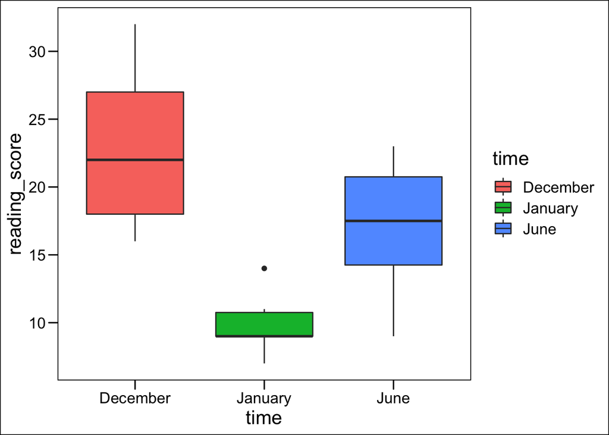

The boxplot is an excellent illustration for the two datasets. We can observe that the mean value which is indicated by middle black line in three boxplots above is not at the same level which in turn show that there is large variation in mean scores for both groups. Furthermore the scores in the january month is very much less than the other two months for both groups. There is one outler for the january month in the two groups. We can analyse the individual groups with the same plot as

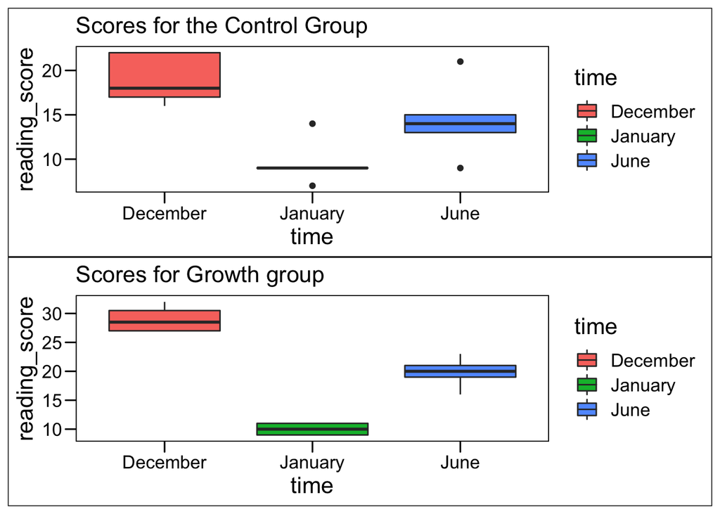

We can clearly see that the mean scores for the growth groups are higher overall in all months from the boxplot above. This has also been the case for 1st and 3rd quartiles in both groups. Fruther corelation between scores can be check by corelation test. *Corelation for reading scores*

```
##
##  Pearson's product-moment correlation
##
## data:  control$reading_score and growth$reading_score
## t = 4.3859, df = 12, p-value = 0.0008871
## alternative hypothesis: true correlation is not equal to 0
## 95 percent confidence interval:
##  0.4354933 0.9286596
## sample estimates:
##       cor
## 0.7847463
```

After Applying the corelation test results show that corelation coefficient value of 0.78. It indicates that there is postive corelation between the reading scores of two groups since this value is between 0.7 and 0.9 indicating that the relationship between the variables is strong. We can say with confidence that there is a relationship because both test’s p-values are much smaller than the significance value of 0.05. It is possible that the correlation is meaningless if variables do not have a linear relationship which can be checked by scatter plot below.

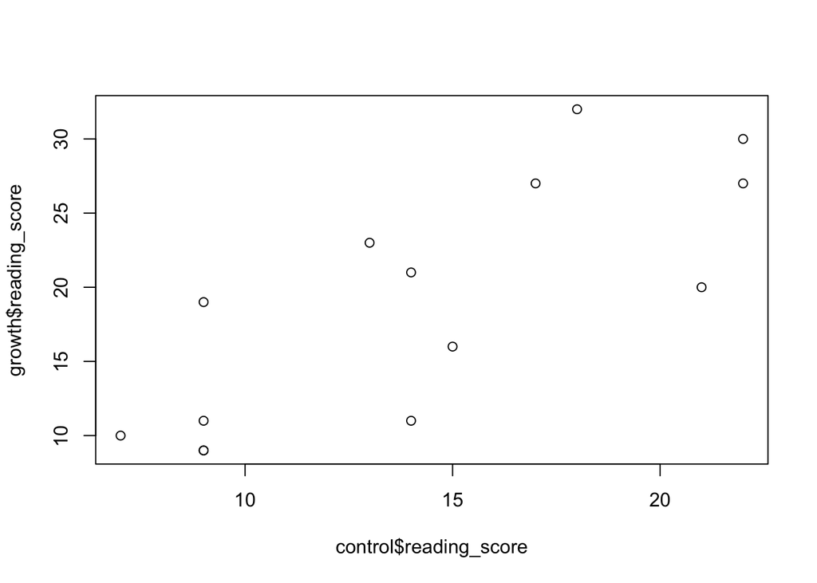

The above scatter plots validates that apparently with increase of reading score of one group the reading score also increases which has been given by corelation test as well. The normality of the read scores for both groups can be visualized with the help density plot below. It will be helpful in the statistical tests if we opt for ANOVA tests.

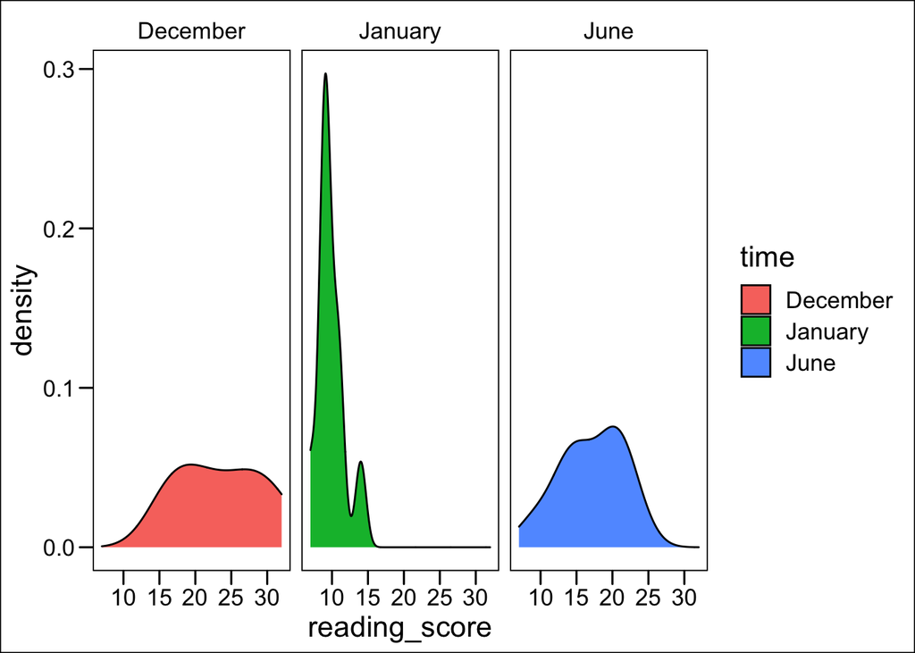

Histogram of reading scores of individual groups.

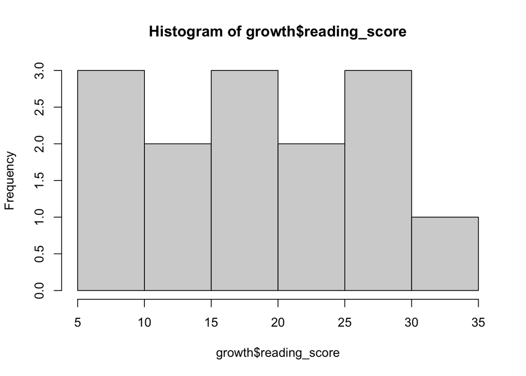

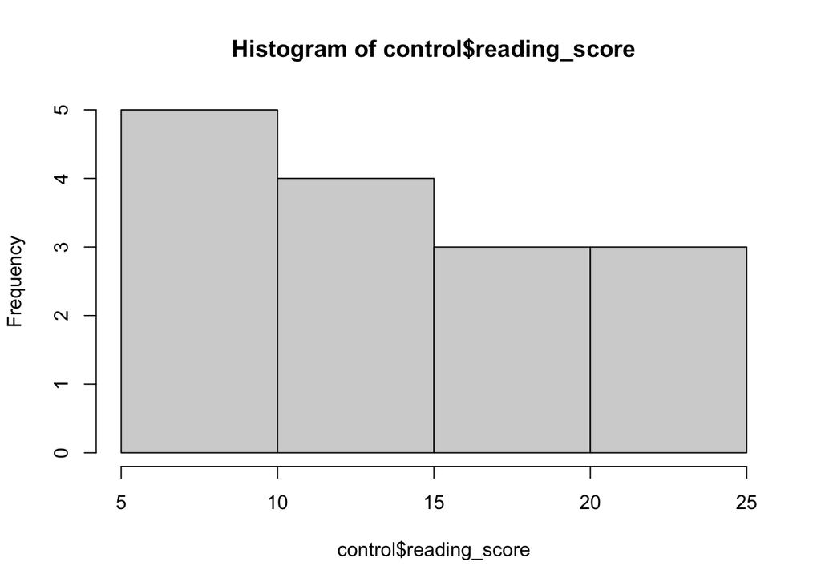

The above histograms indicate that the highest scores are observed for growth group. Similarly number of participants with high reading scores in growth group is higher as compared to control group. None of the scores are normally distributed as well.

The correlation coefficient value of 0.78 indicated that there is high covariance between groups so regression analysis will produce correct results. According to the given condition the two hypothesis are

**Null Hypothesis** The growth group will improve more than the control group does over time

**Alternate Hypothesis** Both groups will improve over time

This hypothesis can be check by mixed Linear regression model to show the differences in scores between control and intervention group. We cannot apply ANOVA test here since the groups compared are 2 which is against the basic requirement for the analysis of varaince. The option could have been a t-test for analysis of means.

We check our first hypotheses defined above and compare the reading scores for two groups.

```
##
## Call:
## lm(formula = growth$reading_score ~ control$reading_score)
##
## Residuals:
##     Min      1Q  Median      3Q     Max
## -7.6663 -3.5473 -0.7782  4.0801  8.4385
##
## Coefficients:
##                       Estimate Std. Error t value Pr(>|t|)
## (Intercept)              1.533      4.206   0.365 0.721818
## control$reading_score    1.224      0.279   4.386 0.000887 ***
## ---
## Signif. codes:  0 '***' 0.001 '**' 0.01 '*' 0.05 '.' 0.1 ' ' 1
##
## Residual standard error: 5.238 on 12 degrees of freedom
##   (1 observation deleted due to missingness)
## Multiple R-squared:  0.6158, Adjusted R-squared:  0.5838
## F-statistic: 19.24 on 1 and 12 DF,  p-value: 0.0008871
```

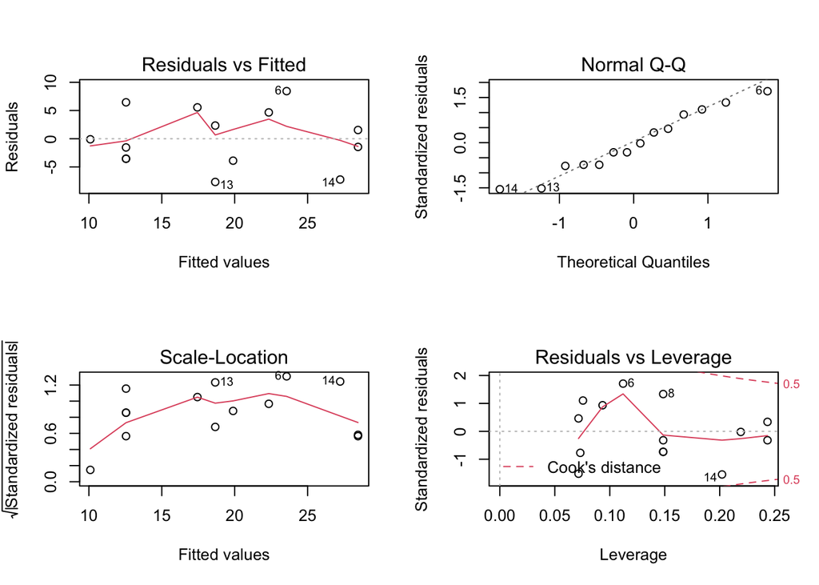

## Question 2

### 2.1 Descriptive results

Before running a factor analysis, it is important to explore the distribution of the data, through mean scores, and how far the average score deviates from the norm (standard deviation). In this section we run descriptive summaries.

|  | vars | n | mean | sd | median | trimmed | mad | min | max | range | skew | kurtosis | se |
| --- | --- | --- | --- | --- | --- | --- | --- | --- | --- | --- | --- | --- | --- |
| CNTSTUID | 1 | 500 | 5.540405e+07 | 2439.6899810 | 55404165.0000 | 5.540406e+07 | 3300.2676000 | 55400007.0000 | 5.540812e+07 | 8113.0000 | -0.0353487 | -1.3215724 | 109.1062528 |
| AGE | 2 | 500 | 1.578112e+01 | 0.2796970 | 15.8300 | 1.578450e+01 | 0.3706500 | 15.2500 | 1.633000e+01 | 1.0800 | -0.0855295 | -1.0633293 | 0.0125084 |
| RESILIENCE | 3 | 481 | -3.750350e-02 | 0.8491172 | -0.0614 | -9.818680e-02 | 0.6763621 | -2.5400 | 2.369300e+00 | 4.9093 | 0.6925647 | 0.7358690 | 0.0387164 |
| COMPETE | 4 | 485 | 6.569710e-02 | 0.9270388 | 0.1956 | 4.544420e-02 | 0.8769579 | -2.3450 | 2.005400e+00 | 4.3504 | 0.0589005 | 0.2644566 | 0.0420947 |
| GFOFAIL | 5 | 483 | 2.307613e-01 | 1.0117618 | 0.1097 | 2.492607e-01 | 1.0541286 | -1.8939 | 1.890500e+00 | 3.7844 | -0.0296047 | -0.4881378 | 0.0460368 |
| HISEI | 6 | 472 | 5.738426e+01 | 20.6198941 | 62.3900 | 5.878032e+01 | 20.9046600 | 14.2100 | 8.870000e+01 | 74.4900 | -0.5670280 | -0.9092040 | 0.9491076 |
| HEDRES | 7 | 493 | -2.132900e-02 | 1.0544390 | 0.0477 | 7.008910e-02 | 1.6314530 | -4.4106 | 1.179300e+00 | 5.5899 | -0.5743895 | 0.2289931 | 0.0474895 |
| PARED | 8 | 477 | 1.312264e+01 | 2.1589055 | 14.0000 | 1.334726e+01 | 1.4826000 | 3.0000 | 1.500000e+01 | 12.0000 | -1.0608398 | 1.1561274 | 0.0988495 |
| SCREADCOMP | 9 | 488 | 6.256450e-02 | 1.0106729 | 0.1222 | 4.666940e-02 | 0.8557567 | -2.4403 | 1.883900e+00 | 4.3242 | 0.0725264 | -0.1001044 | 0.0457510 |
| SCREADDIFF | 10 | 491 | 1.506204e-01 | 1.0475901 | 0.3059 | 1.703288e-01 | 0.8904496 | -1.8876 | 2.775200e+00 | 4.6628 | -0.0218754 | 0.0332926 | 0.0472771 |
| JOYREAD | 11 | 493 | -5.987650e-02 | 1.1559570 | -0.1358 | -6.934530e-02 | 0.9246976 | -2.7316 | 2.613100e+00 | 5.3447 | 0.0756668 | 0.2492023 | 0.0520617 |
| STIMREAD | 12 | 489 | 1.362789e-01 | 0.9594024 | 0.2432 | 1.401313e-01 | 0.8501228 | -2.3003 | 2.087100e+00 | 4.3874 | -0.1390130 | 0.3585063 | 0.0433857 |
| TMINS | 13 | 363 | 1.571915e+03 | 338.9679834 | 1500.0000 | 1.521065e+03 | 185.3250000 | 500.0000 | 3.000000e+03 | 2500.0000 | 1.6577159 | 4.3127298 | 17.7912051 |
| ST188Q01HA | 14 | 480 | 3.106250e+00 | 0.4996476 | 3.0000 | 3.098958e+00 | 0.0000000 | 1.0000 | 4.000000e+00 | 3.0000 | 0.0051398 | 1.7035229 | 0.0228057 |
| ST188Q02HA | 15 | 480 | 3.231250e+00 | 0.6118715 | 3.0000 | 3.273438e+00 | 0.0000000 | 1.0000 | 4.000000e+00 | 3.0000 | -0.4487851 | 0.7416076 | 0.0279280 |
| ST188Q03HA | 16 | 479 | 2.778706e+00 | 0.7550982 | 3.0000 | 2.781818e+00 | 0.0000000 | 1.0000 | 4.000000e+00 | 3.0000 | -0.2515310 | -0.2203333 | 0.0345013 |
| ST188Q06HA | 17 | 479 | 2.759917e+00 | 0.7966856 | 3.0000 | 2.789610e+00 | 0.0000000 | 1.0000 | 4.000000e+00 | 3.0000 | -0.3874875 | -0.1894055 | 0.0364015 |
| ST188Q07HA | 18 | 478 | 3.031381e+00 | 0.6117804 | 3.0000 | 3.062500e+00 | 0.0000000 | 1.0000 | 4.000000e+00 | 3.0000 | -0.5100236 | 1.3750783 | 0.0279822 |
| ST183Q01HA | 19 | 484 | 2.766529e+00 | 0.9265106 | 3.0000 | 2.832474e+00 | 1.4826000 | 1.0000 | 4.000000e+00 | 3.0000 | -0.3492380 | -0.7165204 | 0.0421141 |
| ST183Q02HA | 20 | 485 | 2.723711e+00 | 0.9033653 | 3.0000 | 2.776350e+00 | 1.4826000 | 1.0000 | 4.000000e+00 | 3.0000 | -0.2192383 | -0.7534035 | 0.0410197 |
| ST183Q03HA | 21 | 484 | 2.828512e+00 | 0.9421865 | 3.0000 | 2.907217e+00 | 1.4826000 | 1.0000 | 4.000000e+00 | 3.0000 | -0.3507155 | -0.8145897 | 0.0428267 |
| reading_fluency | 22 | 500 | 1.610200e+01 | 2.7111430 | 17.0000 | 1.649750e+01 | 1.4826000 | 0.0000 | 1.900000e+01 | 19.0000 | -1.7352602 | 4.5304120 | 0.1212460 |
| ST184Q01HA | 23 | 484 | 2.154959e+00 | 0.9001703 | 2.0000 | 2.095361e+00 | 1.4826000 | 1.0000 | 4.000000e+00 | 3.0000 | 0.3378031 | -0.7078958 | 0.0409168 |

As required in question the variable resilience can be checked by frequency bar chart

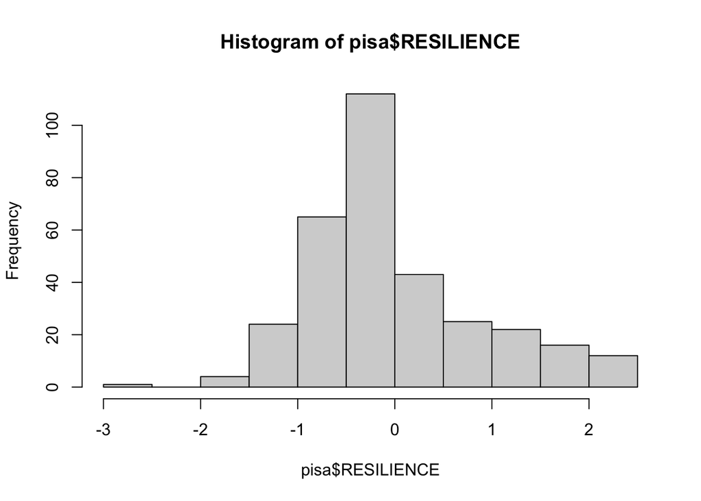

Similarly for the Fear of failure

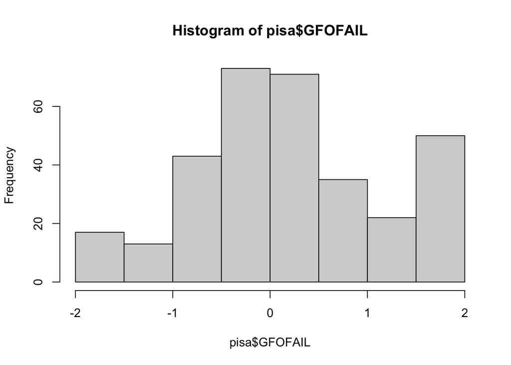

We can remove the columns not needed for analysis. We should remove all other variables other than resilience scales and fail of fear scales as given in question to compute for a two factor structure.

Computing the Summary statistics of remaining columns.

```
##            vars   n mean   sd median trimmed  mad min max range  skew kurtosis
## ST188Q01HA    1 324 3.17 0.50      3    3.16 0.00   2   4     2  0.32     0.32
## ST188Q02HA    2 324 3.28 0.63      3    3.33 0.00   1   4     3 -0.59     0.76
## ST188Q03HA    3 324 2.86 0.77      3    2.88 0.00   1   4     3 -0.31    -0.26
## ST188Q06HA    4 324 2.75 0.83      3    2.78 1.48   1   4     3 -0.35    -0.36
## ST188Q07HA    5 324 3.04 0.62      3    3.07 0.00   1   4     3 -0.49     1.23
## ST183Q01HA    6 324 2.75 0.95      3    2.81 1.48   1   4     3 -0.31    -0.83
## ST183Q02HA    7 324 2.71 0.91      3    2.77 1.48   1   4     3 -0.19    -0.80
## ST183Q03HA    8 324 2.84 0.96      3    2.91 1.48   1   4     3 -0.30    -0.96
##              se
## ST188Q01HA 0.03
## ST188Q02HA 0.04
## ST188Q03HA 0.04
## ST188Q06HA 0.05
## ST188Q07HA 0.03
## ST183Q01HA 0.05
## ST183Q02HA 0.05
## ST183Q03HA 0.05
```

We observed after the variables selection from likert scale that mean values are range 2-3.3 hence there is not much variability in the scale record. The standard error se is also very less although some items are skewed.

Before running principal component analysis we need to have a inspect corelation matrix. In order to have a clear understanding for CFA we should have a look at the correlations among our variables

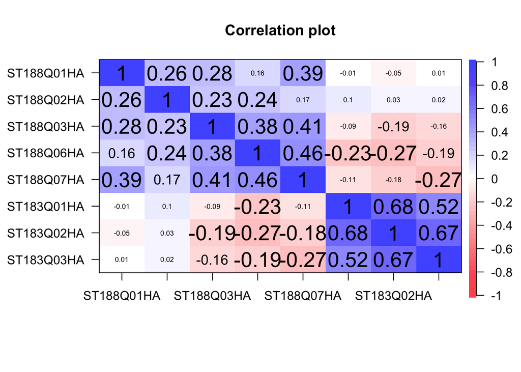

With regards to corelation between Resilience and GFOFAIL likert scales the corelation coefficent values are ranging between 0-0.68 which indicates that all type of postive and no corelation can exist between given values. Some negative values indicate that there are items with negative correlation with each other. To look at diagnostics we run the Bartlett test.

```
##
##  Bartlett test of homogeneity of variances
##
## data:  pisa
## Bartlett's K-squared = 232.83, df = 7, p-value < 2.2e-16
```

The KMO required for the factor analysis is >0.6. We can check it by running `KMO` command below.

```
## Kaiser-Meyer-Olkin factor adequacy
## Call: KMO(r = pisa)
## Overall MSA =  0.69
## MSA for each item =
## ST188Q01HA ST188Q02HA ST188Q03HA ST188Q06HA ST188Q07HA ST183Q01HA ST183Q02HA
##       0.60       0.67       0.81       0.70       0.65       0.73       0.67
## ST183Q03HA
##       0.69
```

**Factor model* Principal component analysis

We now need to determine how many factors will be appropriate to use. We will run a PCA and analyse the eigenvalues. We will then use the Kaiser criterion to decide number of potential components.

```
## [1] 2.7401522 1.8338042 0.8166770 0.8023333 0.6212019 0.5785285 0.3531824
## [8] 0.2541204
```

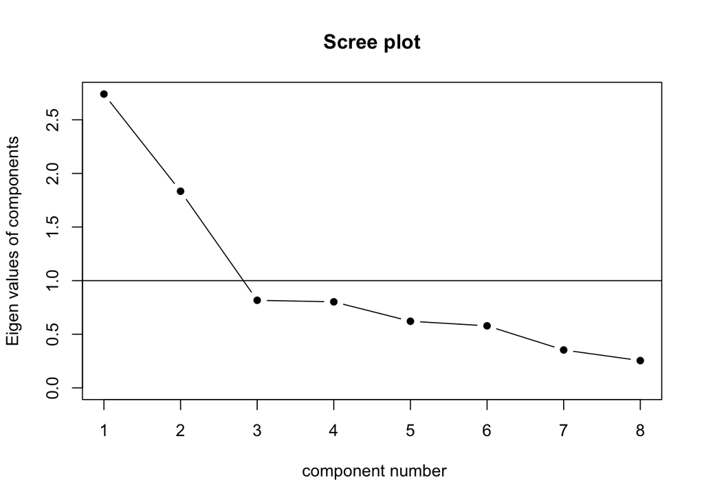

According to two rules of thumb our results may lead to different conclusions. Rather use Horn’s parallel analysis: * generates many random samples of uncorrelated data of the same size as the study sample (i.e. ‘nonsense’ data) * computes a correlation matrix for each of the random samples * these are then factor analysed ans eigenvaues are generated * if an eigenvalue from the study sample is greater than the corresponding eigenvalue from the random, uncorrelated data, we can conclude there is a ‘true’ component explaining the variance in the variables

We use the `fa()` function to with the rotation method equal to rotational since it is not required in this rotation method that the given factors are corelated as in our case.

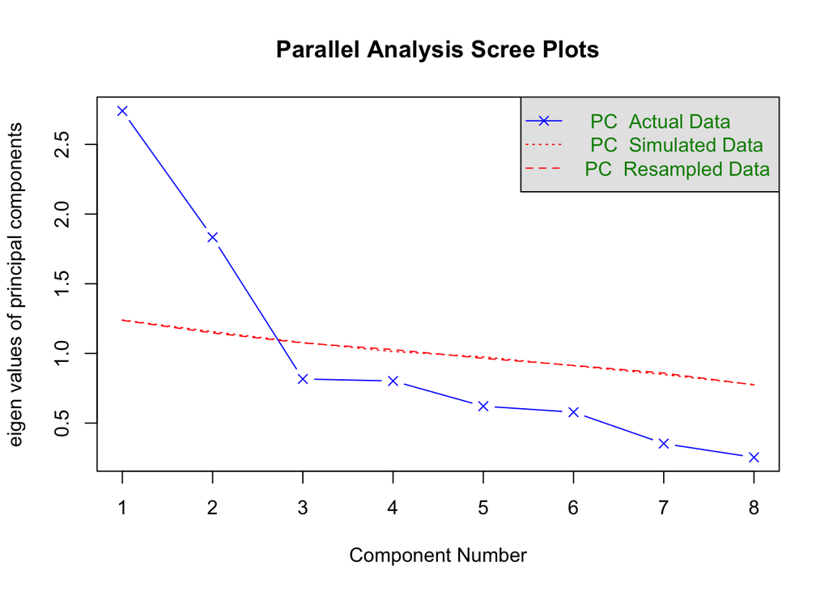

```
## Parallel analysis suggests that the number of factors =  NA  and the number of components =  2
```

Considering the 2 factor solution according to question

```
## [1] 2.7401522 1.8338042 0.8166770 0.8023333 0.6212019 0.5785285 0.3531824
## [8] 0.2541204
```

```
##
## Loadings:
##            PC1    PC2
## ST188Q01HA  0.343  0.556
## ST188Q02HA  0.218  0.565
## ST188Q03HA  0.556  0.442
## ST188Q06HA  0.632  0.303
## ST188Q07HA  0.625  0.441
## ST183Q01HA -0.646  0.537
## ST183Q02HA -0.756  0.482
## ST183Q03HA -0.698  0.452
##
##                  PC1   PC2
## SS loadings    2.740 1.834
## Proportion Var 0.343 0.229
## Cumulative Var 0.343 0.572
```

The items in fear of failure can be problematic in the analysis since they have negative loadings as calculated above. Now we will compute the cumulative variance for these items

| x |
| --- |
| 0.3425190 |
| 0.5717446 |
| 0.6738292 |
| 0.7741208 |
| 0.8517711 |
| 0.9240872 |
| 0.9682349 |
| 1.0000000 |

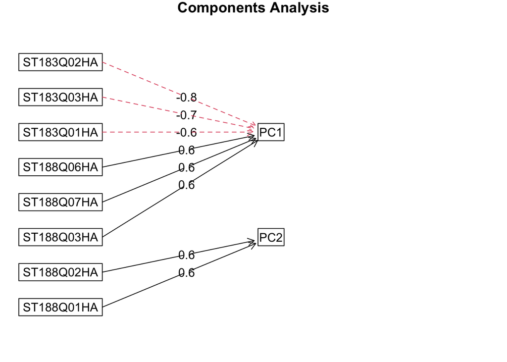

```
## Principal Components Analysis
## Call: principal(r = pisa, nfactors = 2, rotate = "none")
## Standardized loadings (pattern matrix) based upon correlation matrix
##              PC1  PC2   h2   u2 com
## ST188Q01HA  0.34 0.56 0.43 0.57 1.7
## ST188Q02HA  0.22 0.56 0.37 0.63 1.3
## ST188Q03HA  0.56 0.44 0.50 0.50 1.9
## ST188Q06HA  0.63 0.30 0.49 0.51 1.4
## ST188Q07HA  0.63 0.44 0.59 0.41 1.8
## ST183Q01HA -0.65 0.54 0.70 0.30 1.9
## ST183Q02HA -0.76 0.48 0.80 0.20 1.7
## ST183Q03HA -0.70 0.45 0.69 0.31 1.7
##
##                        PC1  PC2
## SS loadings           2.74 1.83
## Proportion Var        0.34 0.23
## Cumulative Var        0.34 0.57
## Proportion Explained  0.60 0.40
## Cumulative Proportion 0.60 1.00
##
## Mean item complexity =  1.7
## Test of the hypothesis that 2 components are sufficient.
##
## The root mean square of the residuals (RMSR) is  0.1
##  with the empirical chi square  192.14  with prob <  5.6e-34
##
## Fit based upon off diagonal values = 0.88
```

#### Internal reliability

ωt - total common variance ωg – variance due to one factor ωh - used for when there are 3 or more factors

```
##
## Three factors are required for identification -- general factor loadings set to be equal.
## Proceed with caution.
## Think about redoing the analysis with alternative values of the 'option' setting.
```

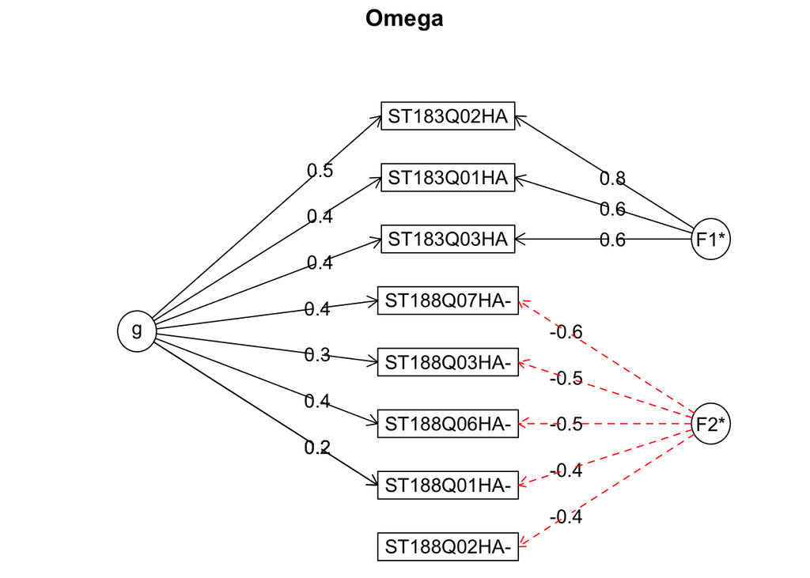

```
## [1] 0.706547
```

```
##         total   general     group
## g   0.7884379 0.3467895 0.4587300
## F1* 0.8374006 0.2403100 0.5970906
## F2* 0.6934474 0.1844601 0.5089873
```

The raw alpha shows a Cronbach’s of α for the overall computed scale of 0.71, which is questionable. This could be due to the that most respondents were biased toward agreement.

## Question 3

It should also be noted that while a high value for Cronbach’s alpha indicates good internal consistency of the items in the scale, it does not mean that the scale is unidimensional. Factor analysis is a method to determine the dimensionality of a scale, in this case a Principal Components Analysis (PCA) will be applied. According to the requirement of the question we need to select two variables reading fluency which will become a dependent variable. The other independent variable/variables can be our choice. We proceed with the reloading of dataset and removing `NaN`.

Viewing the column names to decide about predictor variables for linear regression model

```
##  [1] "CNTSTUID"        "AGE"             "RESILIENCE"      "COMPETE"
##  [5] "GFOFAIL"         "HISEI"           "HEDRES"          "PARED"
##  [9] "SCREADCOMP"      "SCREADDIFF"      "JOYREAD"         "STIMREAD"
## [13] "TMINS"           "ST188Q01HA"      "ST188Q02HA"      "ST188Q03HA"
## [17] "ST188Q06HA"      "ST188Q07HA"      "ST183Q01HA"      "ST183Q02HA"
## [21] "ST183Q03HA"      "reading_fluency" "ST184Q01HA"
```

We can see that there are lots of variables which can have an effect on the reading fluency. For example reading fluency can depend upon Parent’s occupation status `HISEI`, Compeition `COMPETE`, Enjoyment in reading `JOYREAD` etc. We can choose all variables at once or do the analysis one by one.

We will start our analysis for regression model by choosing two variables `COMPETE` and `STIMREAD`. Here the Teachers’ stimulation of reading engagement will serve as control variable which means it will be treated as constant during analysis.

```
##
## Call:
## lm(formula = reading_fluency ~ COMPETE + STIMREAD, data = pisa)
##
## Residuals:
##     Min      1Q  Median      3Q     Max
## -13.545  -1.152   0.556   1.652   3.225
##
## Coefficients:
##             Estimate Std. Error t value Pr(>|t|)
## (Intercept)  16.3510     0.1359 120.331   <2e-16 ***
## COMPETE       0.2186     0.1465   1.492    0.137
## STIMREAD      0.1913     0.1311   1.460    0.145
## ---
## Signif. codes:  0 '***' 0.001 '**' 0.01 '*' 0.05 '.' 0.1 ' ' 1
##
## Residual standard error: 2.411 on 321 degrees of freedom
## Multiple R-squared:  0.01335,    Adjusted R-squared:  0.007203
## F-statistic: 2.172 on 2 and 321 DF,  p-value: 0.1157
```

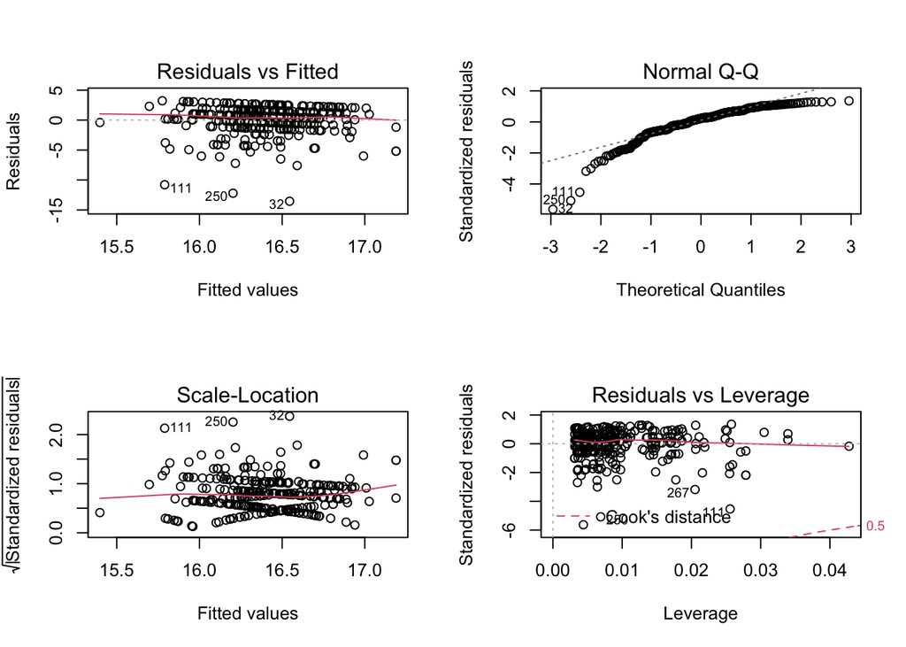

The above results indicate that none of the two variables we chose are good predictors for reading_fleuency since the three aesteics are not shown for the two variables with significant relationship to the dependent variable. Moreoever the p-value is much higher than the assumed significance level of 5% which inturn indicates the dependent variables do not have signficance influence over the dependent variable. Remember that our two hypothesis are

**Null hypothesis $H_o$:** Competetion and Teachers’ stimulation of reading engagement do not have significant effect on reading influency

**ALternate Hypothesis $H_A$**: Competetion and Teachers’ stimulation of reading engagement have significant effect on reading influency Hence we accept our null hypothesis.

Now we will proceed with the just 1 predictor variable.

The two hypothesis now are;

**Null hypothesis $H_o$:** Learning time per week do not have significant effect on reading fluency

**ALternate Hypothesis $H_A$**: Learning time per week have significant effect on reading fluency

```
##
## Call:
## lm(formula = reading_fluency ~ TMINS, data = pisa)
##
## Residuals:
##      Min       1Q   Median       3Q      Max
## -12.4748  -0.9511   0.4497   1.5252   3.6576
##
## Coefficients:
##              Estimate Std. Error t value Pr(>|t|)
## (Intercept) 18.362208   0.649018  28.292  < 2e-16 ***
## TMINS       -0.001258   0.000407  -3.092  0.00217 **
## ---
## Signif. codes:  0 '***' 0.001 '**' 0.01 '*' 0.05 '.' 0.1 ' ' 1
##
## Residual standard error: 2.389 on 322 degrees of freedom
## Multiple R-squared:  0.02883,    Adjusted R-squared:  0.02581
## F-statistic: 9.557 on 1 and 322 DF,  p-value: 0.002165
```

The new test result indicates that reading fluency is influenced by the learning since p-value is less than 0.05. One more indicator is the F-stat which is much higher this time as compared to previous 2 variables. One important thing to notice that even with and without control variables our $R^2$ is very low. We can further plot the two result from the regression plots as

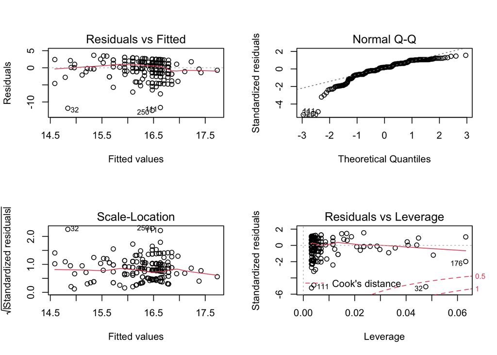

The regression plot indicate that the residuals this time are still spread around the best line which does not show a good correlation for the two variables in our model. QQ plot is much away from the normalized straight indicating a range of outliers in the subset.

In conclusion we reject our null hypothesis that Learning time per week do not have significant effect on reading fluency.

```
##
## Call:
## lm(formula = reading_fluency ~ JOYREAD + COMPETE + STIMREAD,
##     data = pisa)
##
## Residuals:
##      Min       1Q   Median       3Q      Max
## -13.5409  -1.0951   0.5088   1.5929   3.4748
##
## Coefficients:
##             Estimate Std. Error t value Pr(>|t|)
## (Intercept)  16.3547     0.1356 120.648   <2e-16 ***
## JOYREAD       0.1816     0.1118   1.624    0.105
## COMPETE       0.2199     0.1461   1.505    0.133
## STIMREAD      0.1628     0.1319   1.234    0.218
## ---
## Signif. codes:  0 '***' 0.001 '**' 0.01 '*' 0.05 '.' 0.1 ' ' 1
##
## Residual standard error: 2.405 on 320 degrees of freedom
## Multiple R-squared:  0.02142,    Adjusted R-squared:  0.01224
## F-statistic: 2.335 on 3 and 320 DF,  p-value: 0.07387
```

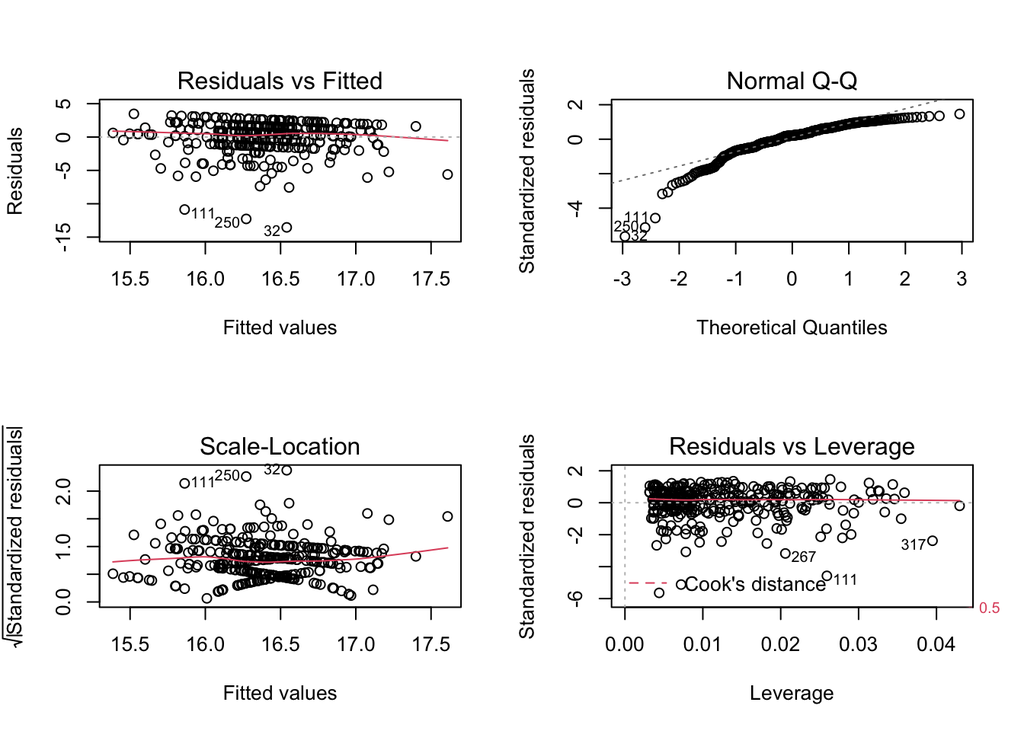

The trend line for residuals is at a minimum slope as compared to previous models which indicates the less residual values. The cook distance graph indicates a value of less than 0.01 which means that the outliers are not affecting our results to large degree. So we conclude that even with addition of new control variables the reading fluency can be dependent upon other factors.

The coefficient values can also be written for the three models as

|  | x |
| --- | --- |
| (Intercept) | 18.3622080 |
| TMINS | -0.0012583 |

|  | x |
| --- | --- |
| (Intercept) | 16.3509697 |
| COMPETE | 0.2185807 |
| STIMREAD | 0.1913300 |

|  | x |
| --- | --- |
| (Intercept) | 16.3547401 |
| JOYREAD | 0.1816142 |
| COMPETE | 0.2199192 |
| STIMREAD | 0.1627531 |